# Task-09(Hypothesis Testing)

### $$\underline{UNDERSTANDING \ \ HYPOTHESIS \ \ TESTING}$$

```python
# Importing the dependencies
import matplotlib.pyplot as plt
import numpy as np
from scipy.stats import norm
from scipy.stats import t
```

### $\underline{Step-I:} \ State \ The \ Hypothesis $

#### Alternate Hypothesis (Bold Claim): $$ H_1 \Rightarrow \ \geq,\ \leq , \neq $$

#### Null Hypothesis (Status Quo/Ground Truth): $$ H_0 \Rightarrow \ >,\ < , = $$

### $\underline{Step-II:}$

- Collect the Sample of size of $\ n $
- Complute the Mean from this sample $ \ \bar{X} $

### $\underline{Step-III:}Compute \ Test \ Statistic $

- If population Standard deviation $(\sigma)$ is known then we use Z-score; $$ \text{Z =}\ \frac{\bar{X}-\mu}{\frac{\sigma}{\sqrt{n}}} $$

If population Standard deviation $(\sigma)$ is unknown then we can sample standard deviation $(s)$ and calculate t-score; $$ \text{t =}\ \frac{\bar{X}-\mu}{\frac{s}{\sqrt{n}}} $$

where, $$ s = \sqrt\frac{\sum({x-\bar{x})^{2}}}{n-1}$$

```python
#User Defined Function For Z Score
def z_score(sample_mean,sample_size,pop_mean,pop_std):
    numerator = sample_mean - pop_mean
    denominator = pop_std/(sample_size)**0.5
    return numerator/denominator
```

```python
#User Defined Function For T-Score
def t_score(sample_mean,sample_size,pop_mean,sample_std):
    numerator = sample_mean - pop_mean
    denominator = sample_std/(sample_size)**0.5
    return numerator/denominator
```

### $\underline{Step-IV:}$ Decide the Significance Level $(\alpha)$ :

Lower $ \alpha $ means you need stronger evidence to reject Null Hypothesis. $$ \alpha = 1 - \text{confidedence} $$

### $\underline{Step-V.1:}$ Apply the Decision Rule :

- If test statistic is **Z-score** : $ \ $
  - Two tailed Z-test: $$ |z| \ > z_{\frac{\alpha}{2}} \ \Rightarrow \ \text{Accept $H_{1}$} \ or \ \ \text{Reject $H_{0}$} $$
  - Right tailed Z-test: $$ z \ > z_{\alpha} \ \Rightarrow \ \text{Accept $H_{1}$} \ or \ \ \text{Reject $H_{0}$} $$
  - Left tailed Z-test: $$ z \ < z_{\alpha} \ \Rightarrow \ \text{Accept $H_{1}$} \ or \ \ \text{Reject $H_{0}$} $$

  </ul> $ \ $
  - If test statistic is **T-score** : $ \ $
    - Two tailed t-test: $$ |t| \ > t_{n-1,\frac{\alpha}{2}} \ \Rightarrow \ \text{Accept $H_{1}$} \ or \ \ \text{Reject $H_{0}$} $$
    - Right tailed Z-test: $$ t \ > t_{(n-1),\frac{\alpha}{2}} \ \Rightarrow \ \text{Accept $H_{1}$} \ or \ \ \text{Reject $H_{0}$} $$
    - Left tailed Z-test: $$ t \ < t_{(n-1),\frac{\alpha}{2}} \ \Rightarrow \ \text{Accept $H_{1}$} \ or \ \ \text{Reject $H_{0}$} $$

      where;
      - $ \ \ \alpha \ \ \ $ is the "Critical Value",
      - **(n-1)** is the degress of Freedom

### $\underline{Step-V.2:}$ Compute p-value - $ P(\text{Test Statistics}|H_{0})$

- For two tailed test: $$ \text{p value} \ = 2*(1.0-cdf(\text{test statistic})) $$
- For one tailed test: $$ \text{p value} \ = (1.0-cdf(\text{test statistic}) $$ Now, $$ if \ (\text{p value} < \alpha) \ \Rightarrow \ \text{Accept $H_{1}$} \ or \ \ \text{Reject $H_{0}$} $$

### Questions : Unknown Standard Deviation

##### **Q-1:**

```
Pista House selling Hyderabadi Chicken Dum biryani claims that each parcel packet has
500 grams of biryani (also mentioned on the label of packet).

You are sceptic of their claims and believe that on average each packet does not contain
500 grams of biryani. How do you prove your claim?
```

#### Step-1 :

#### Alternate Hypothesis (Bold Claim): $$ H_1 \Rightarrow \ \mu \neq 500 \ (\text{Each packet doesnot contain average of 500grm of biryani}) $$

#### Null Hypothesis (Status Quo/Ground Truth): $$ H_0 \Rightarrow \mu = 500 \ (\text{Each packet contain average of 500grm of biryani})$$

#### Step-2 :

- Collect the Sample of size of $\ n $ : $$ [ 490, 220, 470, 510,420,410,490, 498, 508, 480] $$
- Complute the Mean from this sample $ \ \bar{X} $

```python
#Caluclating The Mean
l =  [ 490, 220, 470, 510,420,410,490, 498, 508, 480]
sample_val = l
sample_mean = sum(l)/len(l)
print(sample_mean)
```

```
449.6
```

#### Step-3: Compute Test Statistic

- population standard deviaton is unknown so we go for **T-score:** $$ t = \frac{\bar{x}-\mu}{\frac{s}{\sqrt{n}}} $$

  where, $$ s = \sqrt\frac{\sum({x-\bar{x})^{2}}}{n-1}$$

```python
#Defining the sample and population parameters
sample_size = 10
pop_mean = 500
```

```python
# calculating sample standard deviaton
s = 0
n = sample_size
for i in l:
    s += (i-sample_mean)**2
sample_std = (s/(n-1))**0.5
print(sample_std)
```

```
87.66501899592308
```

```python
# caluculating t-score
t_score_val = t_score(sample_mean,sample_size,pop_mean,sample_std)
print(f"Value of t-score: {t_score_val}")
```

```
Value of t-score: -1.8180432274804879
```

#### Step-4 : Decide $\alpha$

```python
#Two tail test with 95% of confidence
alpha = 1 - 0.95
t_critical = t.ppf(1 - alpha/2, df = 9)
print("t_critical Value :",t_critical)
```

```
t_critical Value : 2.2621571627409915
```

#### Ploting the sampling distribution with rejection regions

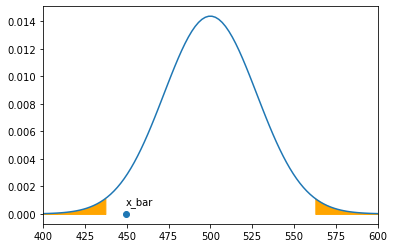

```python
# Defining the x minimum and x maximum
x_min = 400
x_max = 600


# Defining the sampling distribution mean and sampling distribution std
mean = pop_mean
std = sample_std / sample_size**0.5


# Ploting the graph and setting the x limits
x = np.linspace(x_min, x_max, 100)
y = norm.pdf(x, mean, std)
plt.xlim(x_min, x_max)
plt.plot(x, y)


# Computing the left and right critical values (Two tailed Test)
t_critical_left = pop_mean + (-t_critical * std)
t_critical_right = pop_mean + (t_critical * std)


# Shading the left rejection region
x1 = np.linspace(x_min, t_critical_left, 100)
y1 = norm.pdf(x1, mean, std)
plt.fill_between(x1, y1, color='orange')


# Shading the right rejection region
x2 = np.linspace(t_critical_right, x_max, 100)
y2 = norm.pdf(x2, mean, std)
plt.fill_between(x2, y2, color='orange')

# Ploting the sample mean and concluding the results
plt.scatter(sample_mean, 0)
plt.annotate("x_bar", (sample_mean, 0.0007))
plt.show()
```

###### Sample Mean Doesn't fall in the Rejection Region

#### Step-5.1: Two-tailed test:

$$ \text{If} \ |t| > t_{n-1,\frac{\alpha}{2}} \ \Rightarrow \ \text{Accept $H_{1}$} \ or \ \ \text{Reject $H_{0}$} $$

```python
# Conclusion using t- test

if(np.abs(t_score_val) > t_critical):
    print("Reject Null Hypothesis")
else:
    print("Fail to reject Null Hypothesis")
```

```
Fail to reject Null Hypothesis
```

#### Step- 5.2: Compute p-value:

For two tailed test: $$ \text{p value} \ = 2*(1.0-cdf(\text{test statistic})) $$
Now, $$ if \ (\text{p value} < \alpha) \ \Rightarrow \ \text{Accept $H_{1}$} \ or \ \ \text{Reject $H_{0}$} $$

```python
# Conclusion using p test
p_value = 2 * (1.0 - norm.cdf(np.abs(t_score_val)))

print("p_value = ", p_value)

if(p_value < alpha):
    print("Reject Null Hypothesis")
else:
    print("Fail to reject Null Hypothesis")
```

```
p_value =  0.0690575260825983
Fail to reject Null Hypothesis
```

###### Final Summary : We Fail To Reject Null Hypothesis

#### Q-2:

```
You have developed a new Natural Language Processing Algorithms and done a user study.
You claim that the average rating given by the users is greater than 4 on a scale of 1 to 5.
How do you prove this to your client ?
```

#### Step - 1:

- "Alternate Hypothesis (Bold Claim): $$ H_1: \ \text{Average rating}: \ \mu > 4 $$
- "Null Hypothesis (Status Quo): $$ H_0: \ \text{Average rating}: \ \mu \ \leq 4 $$

#### Step - 2 :

- Collect a sample of size n = 20 $$ [4, 3, 5, 4, 5, 3, 5, 5, 4, 2, 4, 5, 5, 4, 4, 5, 3,4,5,2] $$
- Compute sample mean $$ \ \bar{x} = {}? $$

```python
#Collecting and Computing Sample Mean
sample_val = [4,3,5,4,5,3,5,5,4,2,4,5,5,4,4,5,3,4,5,2]
l = sample_val
n = len(l)
sample_size = n
sample_mean = sum(l)/n
sample_mean
```

```
4.05
```

#### Step - 3:Compute Test Statistic-

- If population standard deviatoin($\sigma$) is unknown $$ t = \ \frac{\bar{x} - \mu}{(s \ /{\sqrt{n})}}$$

  where, $$ s = \sqrt\frac{\sum({x-\bar{x})^{2}}}{n-1}$$

```python
#Caluclating the Sample Standard Deviation
s = 0
for i in sample_val:
    s += (i - sample_mean)**2

sample_std = (s / (n-1))**0.5
sample_std
```

```
0.9986833437344549
```

```python
# calculating t-score
pop_mean = 4

t_score_val =  t_score(sample_mean,sample_size,pop_mean,sample_std)
print(f"t-score is {t_score_val}")
```

```
t-score is 0.22390159919342179
```

#### Step-4: decide $\alpha$

```python
#  One tail test with 95% of confidence
alpha = 1 - 0.95
t_critical = t.ppf(1 - alpha, df = 19)
print("t_critical Value :",t_critical)
```

```
t_critical Value : 1.729132811521367
```

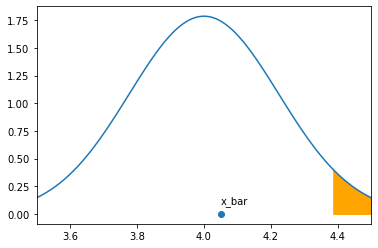

```python
# Ploting the sampling distribution with rejection regions

# Defining the x minimum and x maximum
x_min = 3.5
x_max = 4.5


# Defining the sampling distribution mean and sampling distribution std
mean = pop_mean
std = sample_std / (sample_size**0.5)


# Ploting the graph and setting the x limits
x = np.linspace(x_min, x_max, 100)
y = norm.pdf(x, mean, std)
plt.xlim(x_min, x_max)
plt.plot(x, y)


# Computing the right critical value (Right tailed Test)
t_critical_right = pop_mean + (t_critical * std)


# Shading the right rejection region
x1 = np.linspace(t_critical_right, x_max, 100)
y1 = norm.pdf(x1, mean, std)
plt.fill_between(x1, y1, color='orange')


# Ploting the sample mean and concluding the results
plt.scatter(sample_mean, 0)
plt.annotate("x_bar", (sample_mean, 0.1))
plt.show()
```

###### Sample Mean doesnot fall in the Rejection region

#### Step-5.1: Right Tailed t-test

- Right tailed t-test: $$ t \ > t_{(n-1),\frac{\alpha}{2}} \ \Rightarrow \ \text{Accept $H_{1}$} \ or \ \ \text{Reject $H_{0}$} $$

```python
# Conclusion of this t test

if(np.abs(t_score_val) > t_critical):
    print("Reject Null Hypothesis")
else:
    print("Fail to reject Null Hypothesis")
```

```
Fail to reject Null Hypothesis
```

#### Step- 5.2: Compute p-value:

For two tailed test: $$ \text{p value} \ = 2*(1.0-cdf(\text{test statistic})) $$
Now, $$ if \ (\text{p value} < \alpha) \ \Rightarrow \ \text{Accept $H_{1}$} \ or \ \ \text{Reject $H_{0}$} $$

```python
# Conclusion by p test

p_value = 1.0 - t.cdf(np.abs(t_score_val), df = 19)

print("p_value = ", p_value)

if(p_value < alpha):
    print("Reject Null Hypothesis")
else:
    print("Fail to reject Null Hypothesis")
```

```
p_value =  0.4126119110891797
Fail to reject Null Hypothesis
```

###### Summary: We Failed to Reject the Null Hypothesis $H_0$

### Q-3 :

```
TATA has developed a better fuel management system for the SUV segment.
They claim that with this system, on average the SUV's mileage is at least 15 km/litre ?
```

#### Step - 1:

- "Alternate Hypothesis (Bold Claim): $$ H_1: \ \text{Average mileage}: \ \mu > 15 $$
- "Null Hypothesis (Status Quo): $$ H_0: \ \text{Average mileage}: \ \mu \ \leq 15 $$

#### Step - 2:

- Collect a sample of size n = 15 $$ [ 14.56, 14.7, 15.5, 13.88, 16.1, 14.97, 15.36, 15.81, 14.53, 16.79, 15.78, 16.98, 13.23, 15.43, 13.88] $$
- Compute sample mean $$ \ \bar{x} = {}? $$

```python
sample_val = [ 14.56, 14.7, 15.5, 13.88, 16.1, 14.97, 15.36, 15.81, 14.53, 16.79, 15.78, 16.98, 13.23, 15.43, 13.88]
l = sample_val
n = len(l)
sample_size = n
sample_mean = sum(l)/n
sample_mean
```

```
15.166666666666664
```

#### Step - 3:Compute Test Statistic-

- If population standard deviatoin($\sigma$) is unknown $$ t = \ \frac{\bar{x} - \mu}{(s \ /{\sqrt{n})}}$$

  where, $$ s = \sqrt\frac{\sum({x-\bar{x})^{2}}}{n-1}$$

```python
s = 0
for i in sample_val:
    s += (i - sample_mean)**2

sample_std = (s / (n-1))**0.5
sample_std
```

```
1.0654956369600732
```

```python
# calculating t-score
pop_mean = 15

t_score_val =  t_score(sample_mean,sample_size,pop_mean,sample_std)
print(f"t-score is {t_score_val}")
```

```
t-score is 0.6058187401025293
```

#### Step-4: Decide $\alpha$

```python
#  One tail test with 96% of confidence

alpha = 1 - 0.96
t_critical = t.ppf(1 - alpha, df = 14)
print("t_critical Value :",t_critical)
```

```
t_critical Value : 1.8874961445503944
```

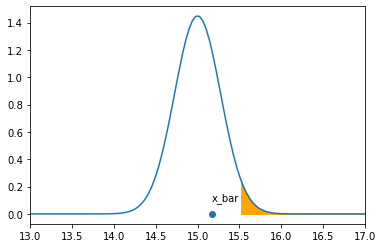

```python
# Ploting the sampling distribution with rejection regions

# Defining the x minimum and x maximum
x_min = 13
x_max = 17


# Defining the sampling distribution mean and sampling distribution std
mean = pop_mean
std = sample_std / (sample_size**0.5)


# Ploting the graph and setting the x limits
x = np.linspace(x_min, x_max, 100)
y = norm.pdf(x, mean, std)
plt.xlim(x_min, x_max)
plt.plot(x, y)


# Computing the right critical value (Right tailed Test)
t_critical_right = pop_mean + (t_critical * std)


# Shading the right rejection region
x1 = np.linspace(t_critical_right, x_max, 100)
y1 = norm.pdf(x1, mean, std)
plt.fill_between(x1, y1, color='orange')


# Ploting the sample mean and concluding the results
plt.scatter(sample_mean, 0)
plt.annotate("x_bar", (sample_mean, 0.1))
plt.show()
```

###### Sample Mean Doesnot fall in the rejection region

#### Step-5.1: Right Tailed t-test

- Right tailed t-test: $$ t \ > t_{(n-1),\frac{\alpha}{2}} \ \Rightarrow \ \text{Accept $H_{1}$} \ or \ \ \text{Reject $H_{0}$} $$

```python
# Conclusion of this t test

if(np.abs(t_score_val) > t_critical):
    print("Reject Null Hypothesis")
else:
    print("Fail to reject Null Hypothesis")
```

```
Fail to reject Null Hypothesis
```

#### Step- 5.2: Compute p-value:

For two tailed test: $$ \text{p value} \ = 2*(1.0-cdf(\text{test statistic})) $$
Now, $$ if \ (\text{p value} < \alpha) \ \Rightarrow \ \text{Accept $H_{1}$} \ or \ \ \text{Reject $H_{0}$} $$

```python
#Conclusion by p test

p_value = 1.0 - t.cdf(np.abs(t_score_val), df = 14)

print("p_value = ", p_value)

if(p_value < alpha):
    print("Reject Null Hypothesis")
else:
    print("Fail to reject Null Hypothesis")
```

```
p_value =  0.2771653186267735
Fail to reject Null Hypothesis
```

###### Summary : We Failed to reject the Null Hypothesis

### Q-4 :

```
You have developed a new Machine Learning Application and claim that on average
it takes less than 100 ms to predict for any future datapoint.
How do you convince your client about this claim?
```

#### Step - 1:

- "Alternate Hypothesis (Bold Claim): $$ H_1: \ \text{Average Time for prediction}: \ \mu < 100 $$
- "Null Hypothesis (Status Quo): $$ H_0: \ \text{Average Time for prediction}: \ \mu \ \geq 100 $$

#### Step - 2:

- Collect a sample of size n = 15 $$ [ 97.8,99,98,92,92.97,89,98.12,92.99,95,96,96.98,99.012,98.4,96.43,95.54] $$
- Compute sample mean $$ \ \bar{x} = {}? $$

```python
sample_val = [ 97.8,99,98,92,92.97,89,98.12,92.99,95,96,96.98,99.012,98.4,96.43,95.54]
l = sample_val
n = len(l)
sample_size = n
sample_mean = sum(l)/n
sample_mean
```

```
95.81613333333333
```

#### Step - 3:Compute Test Statistic-

- If population standard deviatoin($\sigma$) is unknown $$ t = \ \frac{\bar{x} - \mu}{(s \ /{\sqrt{n})}}$$

```python
s = 0
for i in sample_val:
    s += (i - sample_mean)**2

sample_std = (s / (n-1))**0.5
sample_std
```

```
2.9357079911877846
```

```python
# calculatinf t-score
pop_mean = 100

t_score_val =  t_score(sample_mean,sample_size,pop_mean,sample_std)
print(f"t-score is {t_score_val}")
```

```
t-score is -5.519638183154663
```

#### Step-4: Decide $\alpha$

```python
#  One tail (Left Tailed) test with 94% of confidence

alpha = 1 - 0.94
t_critical = t.ppf(1 - alpha, df = 14)
print("t_critical Value :",t_critical)
```

```
t_critical Value : 1.6557819682561565
```

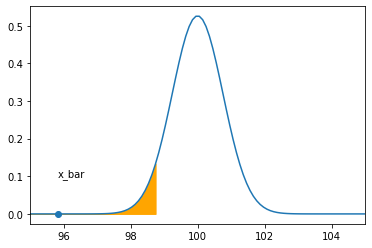

```python
# Ploting the sampling distribution with rejection regions

# Defining the x minimum and x maximum
x_min = 95
x_max = 105


# Defining the sampling distribution mean and sampling distribution std
mean = pop_mean
std = sample_std / (sample_size**0.5)


# Ploting the graph and setting the x limits
x = np.linspace(x_min, x_max, 100)
y = norm.pdf(x, mean, std)
plt.xlim(x_min, x_max)
plt.plot(x, y)


# Computing the left critical value (Left tailed Test)
t_critical_right = pop_mean + (-t_critical * std)


# Shading the left rejection region
x1 = np.linspace(x_min,t_critical_right, 100)
y1 = norm.pdf(x1, mean, std)
plt.fill_between(x1, y1, color='orange')


# Ploting the sample mean and concluding the results
plt.scatter(sample_mean, 0)
plt.annotate("x_bar", (sample_mean, 0.1))
plt.show()
```

#### Sample Mean falls in the Rejection Region

#### Step-5.1: Left Tailed t-test

- Left tailed t-test: $$ t \ < t_{(n-1),\frac{\alpha}{2}} \ \Rightarrow \ \text{Accept $H_{1}$} \ or \ \ \text{Reject $H_{0}$} $$

```python
# Conclusion of this t test

if(np.abs(t_score_val) > t_critical):
    print("Reject Null Hypothesis")
else:
    print("Fail to reject Null Hypothesis")
```

```
Reject Null Hypothesis
```

#### Step- 5.2: Compute p-value:

For two tailed test: $$ \text{p value} \ = 2*(1.0-cdf(\text{test statistic})) $$
Now, $$ if \ (\text{p value} < \alpha) \ \Rightarrow \ \text{Accept $H_{1}$} \ or \ \ \text{Reject $H_{0}$} $$

```python
#Conclusion by p test

p_value = 1.0 - t.cdf(np.abs(t_score_val), df = 14)

print("p_value = ", p_value)

if(p_value < alpha):
    print("Reject Null Hypothesis")
else:
    print("Fail to reject Null Hypothesis")
```

```
p_value =  3.776617078909972e-05
Reject Null Hypothesis
```

###### Summary: We REJECTED the Null Hypothesis $H_0$